# Final Exam Workflow

Luke Ghallahorne

2024-03-18

# Library

```r
library(tidyverse)
# sapply()
library(kableExtra)
# kbl()
library(GGally)
# ggpairs()
library(corrplot)
# corrplot()
library(PNWColors)
# pnw_palette()
library(biotools)
# boxM()
library(vegan)
# vegdist()
library(ape)
# pcoa()
library(dendextend)
```

# Palettes

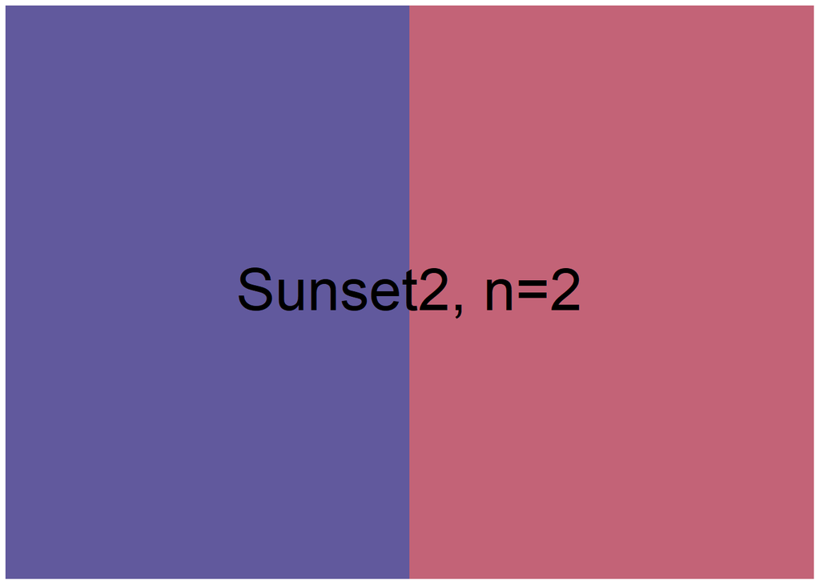

```r
pal1 <- pnw_palette("Sunset2", n = 2)
pal1
```

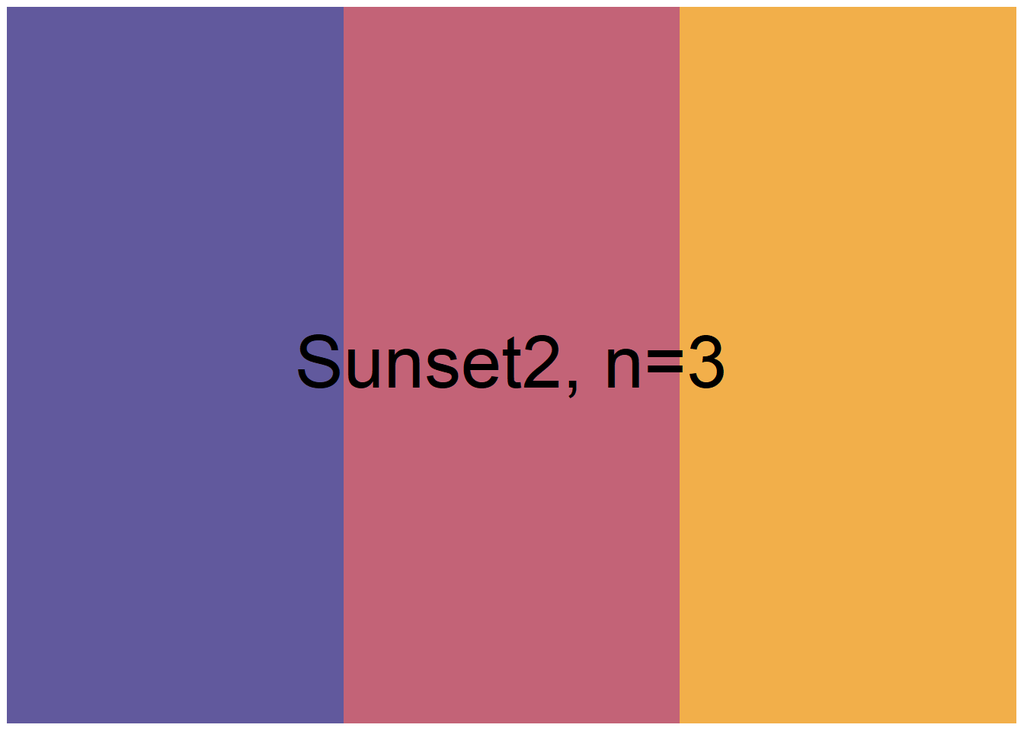

```r
pal2 <- pnw_palette("Sunset2", n = 3)
pal2
```

# Workflow

Visualize Data

- structure & summary statistics //
  - mean, standard deviation//
- distribution //
  - ggpairs: response variables, environmental variables //
  - multivariate normality? //
  - equal variance? -> Box’s M
- corrplot
  - correlation appropriate for multivariate analysis?
- standardization necessary?
  - depends on question and spread of data

Ordination **Normal**

- PCA

**Non-Normal**

- PCoA or nMDS

# Visualize Data

## Loading Data

```r
# Loading abundance data and environmental variables
fungi <- read.csv("Data/fungi.csv")
fungi.env <- read.csv("Data/fungiEnv.csv", stringsAsFactors = TRUE)
```

## Structure and Summary Statistics

```r
# Structure of abundance data
str(fungi)
```

```
## 'data.frame':    32 obs. of  52 variables:
##  $ ID   : chr  "K01" "K02" "K03" "K04" ...
##  $ VT283: int  0 0 0 0 0 0 0 0 0 0 ...
##  $ VT005: int  0 0 0 0 0 0 0 0 0 0 ...
##  $ VT008: int  0 0 0 0 0 0 0 0 0 0 ...
##  $ VT245: int  0 0 4 0 0 0 0 0 0 0 ...
##  $ VT028: int  0 2 0 16 5 0 0 0 0 0 ...
##  $ VT030: int  0 0 0 0 0 0 0 0 0 0 ...
##  $ VT306: int  0 5 0 4 0 0 0 0 6 0 ...
##  $ VT356: int  0 0 0 0 0 0 0 3 0 0 ...
##  $ VT263: int  0 0 0 0 0 0 0 0 0 0 ...
##  $ VT052: int  0 4 1 8 8 10 7 12 55 22 ...
##  $ VT056: int  0 51 53 106 53 6 14 29 16 20 ...
##  $ VT276: int  0 3 0 18 13 0 0 0 5 13 ...
##  $ VT340: int  16 1 0 4 0 0 0 0 0 0 ...
```

[output cut: 38 more lines]

```r
# Summary statistics of abundance data (min, mean, max, quartiles)
summary(fungi)
```

```
##       ID                VT283             VT005            VT008
##  Length:32          Min.   :0.00000   Min.   : 0.000   Min.   : 0.00
##  Class :character   1st Qu.:0.00000   1st Qu.: 0.000   1st Qu.: 0.00
##  Mode  :character   Median :0.00000   Median : 0.000   Median : 0.00
##                     Mean   :0.09375   Mean   : 2.625   Mean   :10.72
##                     3rd Qu.:0.00000   3rd Qu.: 0.000   3rd Qu.:16.00
##                     Max.   :2.00000   Max.   :79.000   Max.   :80.00
##      VT245           VT028            VT030            VT306
##  Min.   : 0.00   Min.   :  0.00   Min.   : 0.000   Min.   : 0.00
##  1st Qu.: 0.00   1st Qu.:  0.00   1st Qu.: 0.000   1st Qu.: 1.50
##  Median : 0.00   Median :  9.50   Median : 0.000   Median :11.00
##  Mean   : 4.75   Mean   : 33.22   Mean   : 4.469   Mean   :14.84
##  3rd Qu.: 5.25   3rd Qu.: 55.75   3rd Qu.: 2.000   3rd Qu.:25.00
##  Max.   :38.00   Max.   :189.00   Max.   :58.000   Max.   :55.00
##      VT356            VT263            VT052          VT056
##  Min.   :0.0000   Min.   : 0.000   Min.   : 0.0   Min.   :  0.0
##  1st Qu.:0.0000   1st Qu.: 0.000   1st Qu.: 2.0   1st Qu.: 16.0
##  Median :0.0000   Median : 0.000   Median : 5.5   Median : 33.5
##  Mean   :0.1562   Mean   : 1.969   Mean   : 8.5   Mean   : 42.5
##  3rd Qu.:0.0000   3rd Qu.: 0.000   3rd Qu.:10.0   3rd Qu.: 57.0
##  Max.   :3.0000   Max.   :31.000   Max.   :55.0   Max.   :141.0
##      VT276           VT340            VT402           VT057
##  Min.   : 0.00   Min.   : 0.000   Min.   : 0.00   Min.   : 0.000
##  1st Qu.: 1.50   1st Qu.: 0.000   1st Qu.: 9.00   1st Qu.: 0.000
##  Median :11.00   Median : 0.000   Median :20.50   Median : 0.000
##  Mean   :10.88   Mean   : 1.062   Mean   :25.16   Mean   : 3.906
##  3rd Qu.:18.00   3rd Qu.: 0.250   3rd Qu.:33.00   3rd Qu.: 6.000
##  Max.   :38.00   Max.   :16.000   Max.   :98.00   Max.   :36.000
##      VT193            VT423          VT212            VT216
##  Min.   : 26.00   Min.   : 0.0   Min.   :0.0000   Min.   : 0.000
##  1st Qu.: 52.25   1st Qu.:19.5   1st Qu.:0.0000   1st Qu.: 0.000
##  Median : 72.50   Median :28.5   Median :0.0000   Median : 0.000
##  Mean   : 93.22   Mean   :33.0   Mean   :0.3125   Mean   : 0.875
##  3rd Qu.: 95.50   3rd Qu.:41.5   3rd Qu.:0.0000   3rd Qu.: 0.000
##  Max.   :293.00   Max.   :84.0   Max.   :4.0000   Max.   :13.000
##      VT214            VT153            VT115            VT135
##  Min.   :0.0000   Min.   : 0.000   Min.   :  0.00   Min.   : 0.000
##  1st Qu.:0.0000   1st Qu.: 0.000   1st Qu.: 18.00   1st Qu.: 0.000
##  Median :0.0000   Median : 0.000   Median : 31.00   Median : 0.000
##  Mean   :0.1875   Mean   : 4.812   Mean   : 42.44   Mean   : 3.125
```

[output cut: 36 more lines]

```
##  Max.   :40.000   Max.   :17.000   Max.   :42.000   Max.   :6.0000
##      VT165            VT177            VT197           VT234
##  Min.   :  0.00   Min.   :0.0000   Min.   : 0.00   Min.   :0.000
##  1st Qu.: 22.50   1st Qu.:0.0000   1st Qu.: 9.00   1st Qu.:0.000
##  Median : 31.50   Median :0.0000   Median :20.50   Median :0.000
##  Mean   : 45.03   Mean   :0.2812   Mean   :21.12   Mean   :0.875
##  3rd Qu.: 65.50   3rd Qu.:0.0000   3rd Qu.:25.50   3rd Qu.:0.000
##  Max.   :137.00   Max.   :5.0000   Max.   :70.00   Max.   :9.000
##      VT303            VT063            VT281            VT349
##  Min.   : 0.000   Min.   : 0.000   Min.   :  0.00   Min.   :  0.00
##  1st Qu.: 0.000   1st Qu.: 0.000   1st Qu.: 24.75   1st Qu.:  0.00
##  Median : 0.000   Median : 0.000   Median :163.00   Median :  0.00
##  Mean   : 1.375   Mean   : 1.094   Mean   :214.59   Mean   : 26.84
##  3rd Qu.: 0.000   3rd Qu.: 0.500   3rd Qu.:405.75   3rd Qu.: 16.25
##  Max.   :44.000   Max.   :11.000   Max.   :677.00   Max.   :159.00
```

```r
# Standard deviation
sapply(fungi[,-1], FUN = sd)
```

```
##       VT283       VT005       VT008       VT245       VT028       VT030
##   0.3901509  13.9509509  19.5468575   8.8244528  47.1885267  12.1016778
##       VT306       VT356       VT263       VT052       VT056       VT276
##  14.9172110   0.6278162   6.1617152  11.0599539  33.7179956  10.0120895
##       VT340       VT402       VT057       VT193       VT423       VT212
##   3.0047006  23.0190796   7.0131645  67.6274111  21.2390389   0.8957786
##       VT216       VT214       VT153       VT115       VT135       VT114
##   2.4593469   0.7378041   8.9024734  39.9547627   4.7024359  72.0925075
##       VT064       VT143       VT125       VT222       VT160       VT113
##   2.5334456  49.3081162   4.0449840   5.7178272  15.8358515 131.2471467
##       VT166       VT219       VT130       VT294       VT416       VT409
##   3.2264969   9.2204191   5.2594002   7.0710678   4.5467997   0.4212118
##       VT195       VT108       VT188       VT140       VT137       VT155
## 150.3137813  42.4415632   7.5166482  10.3537725   4.2024139  11.3357840
##       VT159       VT165       VT177       VT197       VT234       VT303
##   1.1704528  34.6423984   1.1139692  15.7945479   2.4983866   7.7781746
##       VT063       VT281       VT349
##   2.3604179 200.5747965  50.4995109
```

```r
# Maxima
sapply(fungi[,-1], FUN = max)
```

```
## VT283 VT005 VT008 VT245 VT028 VT030 VT306 VT356 VT263 VT052 VT056 VT276 VT340
##     2    79    80    38   189    58    55     3    31    55   141    38    16
## VT402 VT057 VT193 VT423 VT212 VT216 VT214 VT153 VT115 VT135 VT114 VT064 VT143
##    98    36   293    84     4    13     3    42   155    15   369    11   266
## VT125 VT222 VT160 VT113 VT166 VT219 VT130 VT294 VT416 VT409 VT195 VT108 VT188
##    17    19    65   489    14    34    21    40    25     2   593   190    30
## VT140 VT137 VT155 VT159 VT165 VT177 VT197 VT234 VT303 VT063 VT281 VT349
##    40    17    42     6   137     5    70     9    44    11   677   159
```

```r
# Means
sapply(fungi[,-1], FUN = mean)
```

```
##     VT283     VT005     VT008     VT245     VT028     VT030     VT306     VT356
##   0.09375   2.62500  10.71875   4.75000  33.21875   4.46875  14.84375   0.15625
##     VT263     VT052     VT056     VT276     VT340     VT402     VT057     VT193
##   1.96875   8.50000  42.50000  10.87500   1.06250  25.15625   3.90625  93.21875
##     VT423     VT212     VT216     VT214     VT153     VT115     VT135     VT114
##  33.00000   0.31250   0.87500   0.18750   4.81250  42.43750   3.12500  24.65625
##     VT064     VT143     VT125     VT222     VT160     VT113     VT166     VT219
##   1.03125 121.75000   1.65625   4.62500  23.00000 153.84375   0.90625   6.87500
##     VT130     VT294     VT416     VT409     VT195     VT108     VT188     VT140
##   4.12500   1.25000   1.18750   0.12500 169.65625  85.06250   8.12500   8.65625
##     VT137     VT155     VT159     VT165     VT177     VT197     VT234     VT303
##   2.78125   6.37500   0.28125  45.03125   0.28125  21.12500   0.87500   1.37500
##     VT063     VT281     VT349
##   1.09375 214.59375  26.84375
```

```r
min(sapply(fungi[,-1], FUN = max))
```

```
## [1] 2
```

```r
max(sapply(fungi[,-1], FUN = mean))
```

```
## [1] 214.5938
```

```r
# Presentation table of summary statistics
Taxa <- t(colnames(fungi[,-1]))
Min <- t(sapply(fungi[,-1], FUN = min))
Mean <- t(sapply(fungi[,-1], FUN = mean))
Max <- t(sapply(fungi[,-1], FUN = max))
SD <- t(sapply(fungi[,-1], FUN = sd))

fungi.summ <- rbind.data.frame(Min,
                               Mean,
                               Max,
                               SD)
colnames(fungi.summ) <- Taxa
rownames(fungi.summ) <- c("Min", "Mean", "Max", "SD")
fungi.summ
```

```
##          VT283    VT005    VT008     VT245     VT028    VT030    VT306
## Min  0.0000000  0.00000  0.00000  0.000000   0.00000  0.00000  0.00000
## Mean 0.0937500  2.62500 10.71875  4.750000  33.21875  4.46875 14.84375
## Max  2.0000000 79.00000 80.00000 38.000000 189.00000 58.00000 55.00000
## SD   0.3901509 13.95095 19.54686  8.824453  47.18853 12.10168 14.91721
##          VT356     VT263    VT052   VT056    VT276     VT340    VT402     VT057
## Min  0.0000000  0.000000  0.00000   0.000  0.00000  0.000000  0.00000  0.000000
## Mean 0.1562500  1.968750  8.50000  42.500 10.87500  1.062500 25.15625  3.906250
## Max  3.0000000 31.000000 55.00000 141.000 38.00000 16.000000 98.00000 36.000000
## SD   0.6278162  6.161715 11.05995  33.718 10.01209  3.004701 23.01908  7.013164
##          VT193    VT423     VT212     VT216     VT214     VT153     VT115
## Min   26.00000  0.00000 0.0000000  0.000000 0.0000000  0.000000   0.00000
## Mean  93.21875 33.00000 0.3125000  0.875000 0.1875000  4.812500  42.43750
## Max  293.00000 84.00000 4.0000000 13.000000 3.0000000 42.000000 155.00000
## SD    67.62741 21.23904 0.8957786  2.459347 0.7378041  8.902473  39.95476
##          VT135     VT114     VT064     VT143     VT125     VT222    VT160
## Min   0.000000   0.00000  0.000000  54.00000  0.000000  0.000000  0.00000
## Mean  3.125000  24.65625  1.031250 121.75000  1.656250  4.625000 23.00000
## Max  15.000000 369.00000 11.000000 266.00000 17.000000 19.000000 65.00000
## SD    4.702436  72.09251  2.533446  49.30812  4.044984  5.717827 15.83585
##         VT113     VT166     VT219   VT130     VT294   VT416     VT409    VT195
## Min    8.0000  0.000000  0.000000  0.0000  0.000000  0.0000 0.0000000  14.0000
## Mean 153.8438  0.906250  6.875000  4.1250  1.250000  1.1875 0.1250000 169.6562
## Max  489.0000 14.000000 34.000000 21.0000 40.000000 25.0000 2.0000000 593.0000
## SD   131.2471  3.226497  9.220419  5.2594  7.071068  4.5468 0.4212118 150.3138
##          VT108     VT188    VT140     VT137    VT155    VT159     VT165
## Min   16.00000  0.000000  0.00000  0.000000  0.00000 0.000000   0.00000
## Mean  85.06250  8.125000  8.65625  2.781250  6.37500 0.281250  45.03125
## Max  190.00000 30.000000 40.00000 17.000000 42.00000 6.000000 137.00000
## SD    42.44156  7.516648 10.35377  4.202414 11.33578 1.170453  34.64240
##         VT177    VT197    VT234     VT303     VT063    VT281     VT349
## Min  0.000000  0.00000 0.000000  0.000000  0.000000   0.0000   0.00000
## Mean 0.281250 21.12500 0.875000  1.375000  1.093750 214.5938  26.84375
## Max  5.000000 70.00000 9.000000 44.000000 11.000000 677.0000 159.00000
## SD   1.113969 15.79455 2.498387  7.778175  2.360418 200.5748  50.49951
```

```r
kbl(fungi.summ, digits = 2) |>
  kable_styling(bootstrap_options = c("striped", "hover", "condensed"))
```

|  | VT283 | VT005 | VT008 | VT245 | VT028 | VT030 | VT306 | VT356 | VT263 | VT052 | VT056 | VT276 | VT340 | VT402 | VT057 | VT193 | VT423 | VT212 | VT216 | VT214 | VT153 | VT115 | VT135 | VT114 | VT064 | VT143 | VT125 | VT222 | VT160 | … |
| --- | --- | --- | --- | --- | --- | --- | --- | --- | --- | --- | --- | --- | --- | --- | --- | --- | --- | --- | --- | --- | --- | --- | --- | --- | --- | --- | --- | --- | --- | --- |
| Min | 0.00 | 0.00 | 0.00 | 0.00 | 0.00 | 0.00 | 0.00 | 0.00 | 0.00 | 0.00 | 0.00 | 0.00 | 0.00 | 0.00 | 0.00 | 26.00 | 0.00 | 0.00 | 0.00 | 0.00 | 0.00 | 0.00 | 0.00 | 0.00 | 0.00 | 54.00 | 0.00 | 0.00 | 0.00 | … |
| Mean | 0.09 | 2.62 | 10.72 | 4.75 | 33.22 | 4.47 | 14.84 | 0.16 | 1.97 | 8.50 | 42.50 | 10.88 | 1.06 | 25.16 | 3.91 | 93.22 | 33.00 | 0.31 | 0.88 | 0.19 | 4.81 | 42.44 | 3.12 | 24.66 | 1.03 | 121.75 | 1.66 | 4.62 | 23.00 | … |
| Max | 2.00 | 79.00 | 80.00 | 38.00 | 189.00 | 58.00 | 55.00 | 3.00 | 31.00 | 55.00 | 141.00 | 38.00 | 16.00 | 98.00 | 36.00 | 293.00 | 84.00 | 4.00 | 13.00 | 3.00 | 42.00 | 155.00 | 15.00 | 369.00 | 11.00 | 266.00 | 17.00 | 19.00 | 65.00 | … |
| SD | 0.39 | 13.95 | 19.55 | 8.82 | 47.19 | 12.10 | 14.92 | 0.63 | 6.16 | 11.06 | 33.72 | 10.01 | 3.00 | 23.02 | 7.01 | 67.63 | 21.24 | 0.90 | 2.46 | 0.74 | 8.90 | 39.95 | 4.70 | 72.09 | 2.53 | 49.31 | 4.04 | 5.72 | 15.84 | … |

```r
# Structure of environmental variables
str(fungi.env)
```

```
## 'data.frame':    32 obs. of  6 variables:
##  $ ID   : Factor w/ 32 levels "K01","K02","K03",..: 1 2 3 4 5 6 7 8 9 10 ...
##  $ moist: Factor w/ 2 levels "dry","wet": 1 1 1 1 1 1 1 1 1 1 ...
##  $ pop  : Factor w/ 4 levels "jumbo","mpg",..: 1 1 1 1 2 2 2 4 4 4 ...
##  $ shoot: num  0.622 0.526 1.099 0.541 0.482 ...
##  $ root : num  0.792 0.829 1.824 1.218 0.944 ...
##  $ total: num  1.41 1.35 2.92 1.76 1.43 ...
```

```r
# Summary statistics of environmental variables
summary(fungi.env)
```

```
##        ID     moist        pop        shoot             root
##  K01    : 1   dry:16   jumbo :9   Min.   :0.3480   Min.   :0.1965
##  K02    : 1   wet:16   mpg   :7   1st Qu.:0.5383   1st Qu.:0.7762
##  K03    : 1            portal:8   Median :0.7340   Median :0.9630
##  K04    : 1            sandy :8   Mean   :0.7863   Mean   :0.9739
##  K05    : 1                       3rd Qu.:1.0695   3rd Qu.:1.1438
##  K06    : 1                       Max.   :1.2500   Max.   :1.8920
##  (Other):26
##      total
##  Min.   :0.7479
##  1st Qu.:1.3665
##  Median :1.7387
##  Mean   :1.7603
##  3rd Qu.:2.0960
##  Max.   :3.1420
##
```

Environmental variables include two categorical variables - soil treatment (dry or wet) and seed population of origin - as well as three continuous variables - shoot, root, and total biomass, in grams. Soil treatments are even groups of 16 plants each. Plants included 9 from the jumbo population, 7 from mpg, 8 from portal, and 8 from sandy.

## Variables

Environmental Variables:

- moist: wet or dry soil treatment
- pop: plant population from which seed was sourced
  - jumbo, mpg, portal, or sandy
- shoot: dry weight of aboveground tissue (g)
- root: dry weight of belowground tissue (g)
- total: dry weight of whole plant (g)

Response Variables:

- sequence abundances for 51 AM fungi virtual taxa

## Distributions

### Fungi[,2:11]

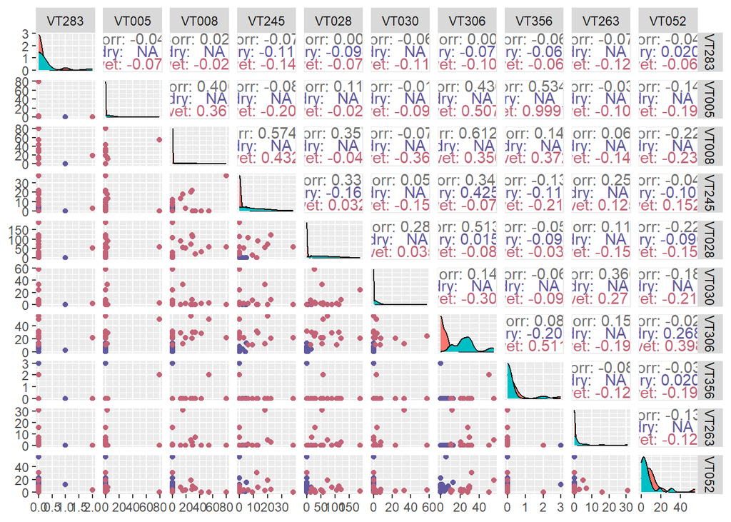

```r
ggpairs(fungi[,2:11], aes(col = fungi.env$moist)) +
  scale_color_manual(values = pal1)
```

### Fungi[,12:21]

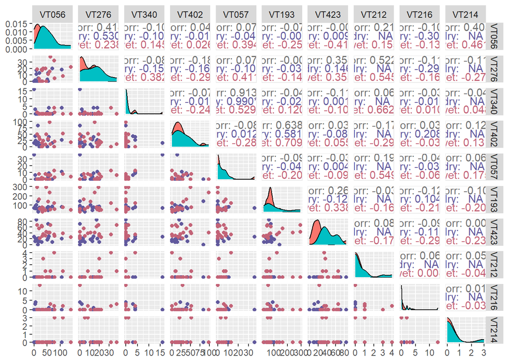

```r
ggpairs(fungi[,12:21], aes(col = fungi.env$moist)) +
  scale_color_manual(values = pal1)
```

### Fungi[,22:31]

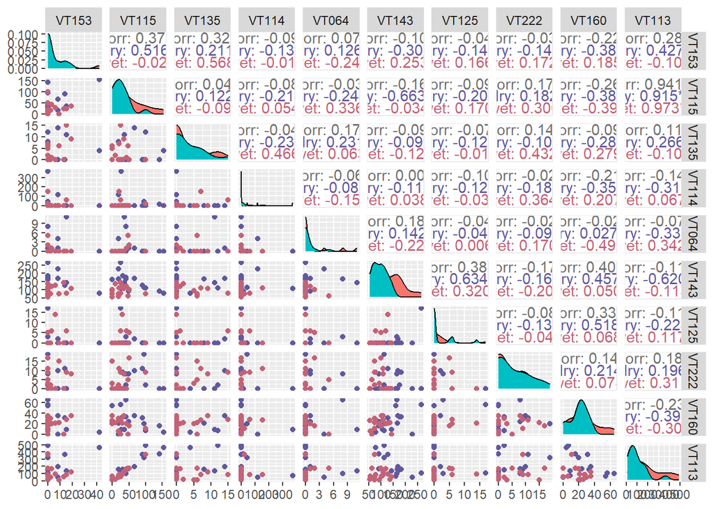

```r
ggpairs(fungi[,22:31], aes(col = fungi.env$moist)) +
  scale_color_manual(values = pal1)
```

### Fungi[,32:41]

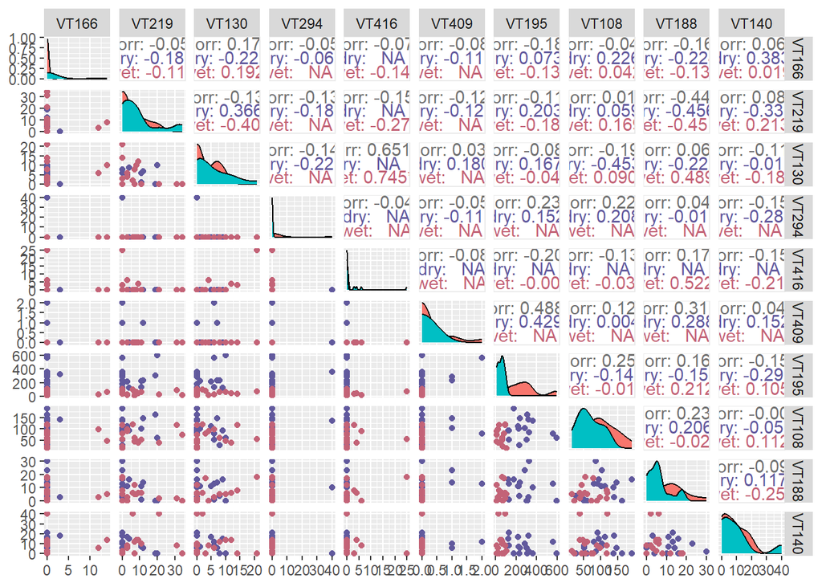

```r
ggpairs(fungi[,32:41], aes(col = fungi.env$moist)) +
  scale_color_manual(values = pal1)
```

### Fungi[,42:51]

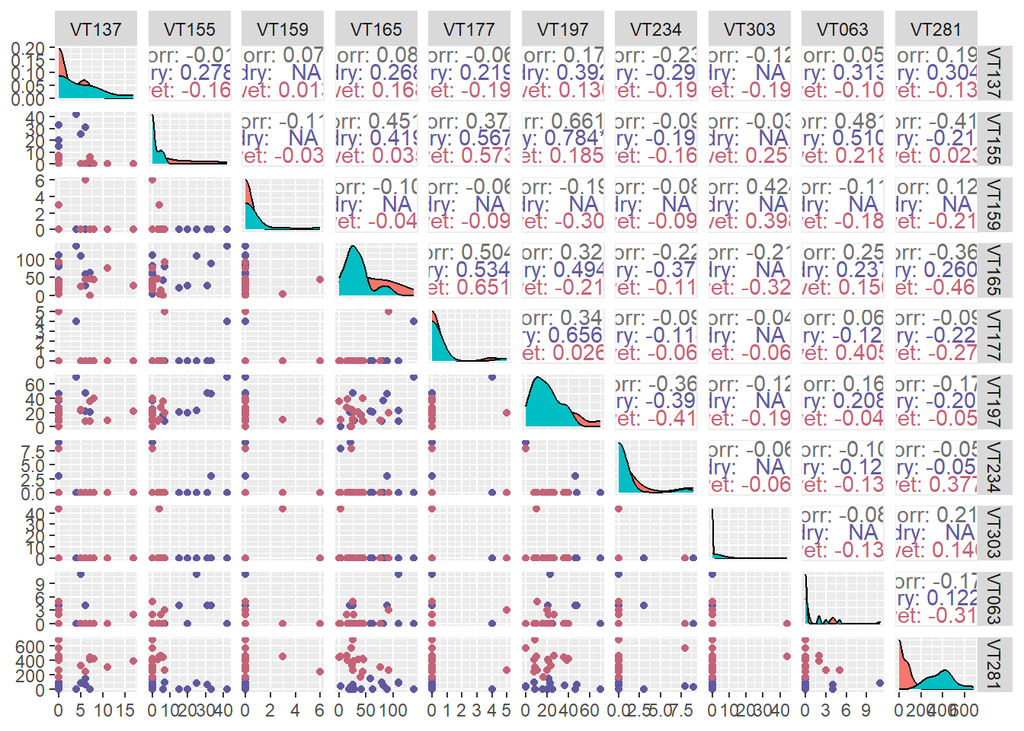

```r
ggpairs(fungi[,42:51], aes(col = fungi.env$moist)) +
  scale_color_manual(values = pal1)
```

Due to the number of response variables, I broke up the pairwise plots into groups of 10 to get a general idea of the distributions and correlations between taxa. Color indicates wet or dry treatment.

The response variables have highly non-normal distributions, skewing toward zeros and low values across taxa. A few pairwise plots have a roughly elliptical shape but the majority show strong tendencies toward zeroes. This is unsurprising given the nature of the response data as virtual taxa abundances.

## Correlation

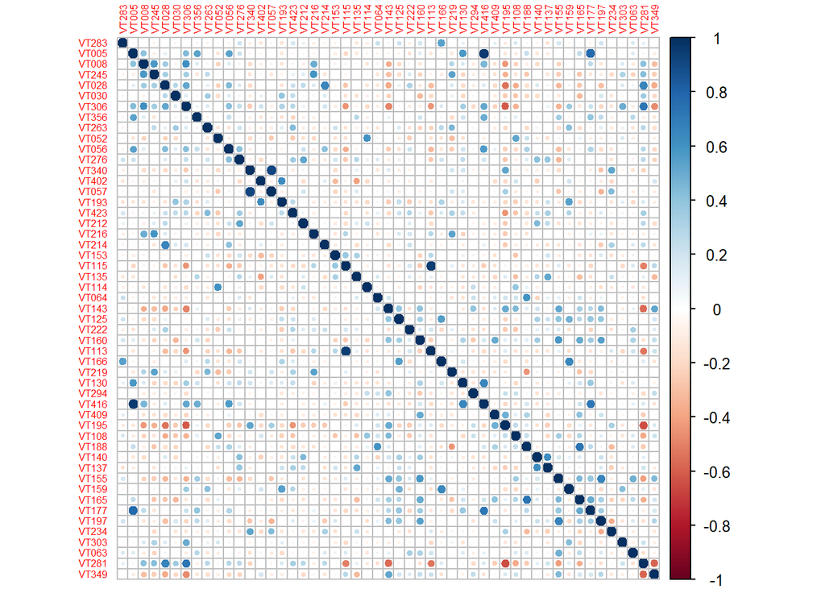

```r
M <- cor(fungi[,-1])
corrplot(M, tl.cex = 0.5)
```

```r
cor.test(fungi$VT416, fungi$VT005)
```

```
##
##  Pearson's product-moment correlation
##
## data:  fungi$VT416 and fungi$VT005
## t = 17.358, df = 30, p-value < 2.2e-16
## alternative hypothesis: true correlation is not equal to 0
## 95 percent confidence interval:
##  0.9063396 0.9773441
## sample estimates:
##       cor
## 0.9536474
```

```r
cor.test(fungi$VT113, fungi$VT115)
```

```
##
##  Pearson's product-moment correlation
##
## data:  fungi$VT113 and fungi$VT115
## t = 15.288, df = 30, p-value = 1.056e-15
## alternative hypothesis: true correlation is not equal to 0
## 95 percent confidence interval:
##  0.8823563 0.9712686
## sample estimates:
##       cor
## 0.9414058
```

```r
cor.test(fungi$VT057, fungi$VT340)
```

```
##
##  Pearson's product-moment correlation
##
## data:  fungi$VT057 and fungi$VT340
## t = 12.23, df = 30, p-value = 3.467e-13
## alternative hypothesis: true correlation is not equal to 0
## 95 percent confidence interval:
##  0.8272074 0.9568444
## sample estimates:
##       cor
## 0.9126535
```

Correlation between AM fungi taxa varies from near zero for many pairs to very high correlation. Many pairs are moderately correlated, justifying the use of multivariate methods to assess differences in AM fungi communities.

Three pairs of taxa are very highly correlated: VT416 and VT005 (r = 0.95, t<sub>30</sub> = 17.4, p < 0.001), VT113 and VT115 (r = 0.94, t<sub>30</sub> = 15.3, p < 0.001), and VT057 and VT340 (r = 0.91, t<sub>30</sub> = 12.2, p < 0.001).

## Box’s M

Because the number of observations (n = 32, i.e., knapweed plants) is less than the number of variables (p = 51, i.e., AM fungi virtual taxa), a Box’s M test for homogeneity of covariance matrices was unsuccessful.

Since these data are not multivariate normally distributed, they do not satisfy the assumptions of analyses like Principle Components Analysis (PCA) or Multivariate Analysis of Variance (MANOVA). As such, equal variance in response variables among explanatory variables (i.e., dry and wet soil treatments) is not a prerequisite for other analyses like PCoA, nMDS, and PERMANOVA.

# Ordination

## Choosing Ordination Method

As the data do not satisfy the assumption of normality, a Principle Component Analysis (PCA) is inappropriate for these data.

Both Principle Coordinates Analysis (PCoA) and non-metric Multidimensional Scaling (nMDS) rely on distance/dissimilarity matrices to construct ordination axes. I chose Bray-Curtis dissimilarity measures over Euclidean or standardized Euclidean measures because Bray-Curtis better accounts for repeating zeros often seen in community abundance data such as the AM fungi data.

### PCoA

```r
# response variable matrix
Y <- as.matrix(fungi[,-1])
# Distance/dissimilarity matrix with Bray-Curtis distances
fungi.dist <- vegdist(Y, method = "bray")
# PCoA on distance/dissimilarity matrix
fungi.pcoa <- pcoa(fungi.dist)
fungi.pcoa$values[,1:6]
```

```
##     Eigenvalues  Relative_eig Rel_corr_eig Broken_stick Cum_corr_eig
## 1   1.805995013  0.4817943158  0.329874557  0.133166238    0.3298746
## 2   0.551551241  0.1471400811  0.108315963  0.099832904    0.4381905
## 3   0.285557531  0.0761796097  0.061336423  0.083166238    0.4995269
## 4   0.244281601  0.0651682237  0.054046310  0.072055127    0.5535733
## 5   0.205188056  0.0547390432  0.047141647  0.063721793    0.6007149
## 6   0.184857731  0.0493154208  0.043550926  0.057055127    0.6442658
## 7   0.144578930  0.0385700436  0.036436925  0.051499571    0.6807028
## 8   0.126035420  0.0336230988  0.033161789  0.046737666    0.7138645
## 9   0.109845362  0.0293039962  0.030302317  0.042571000    0.7441669
## 10  0.069036463  0.0184172023  0.023094690  0.038867296    0.7672615
## 11  0.058454360  0.0155941617  0.021225690  0.035533963    0.7884872
## 12  0.050699176  0.0135252726  0.019855977  0.032503660    0.8083432
## 13  0.040010648  0.0106738406  0.017968180  0.029725882    0.8263114
## 14  0.039393726  0.0105092611  0.017859220  0.027161779    0.8441706
```

[output cut: 51 more lines]

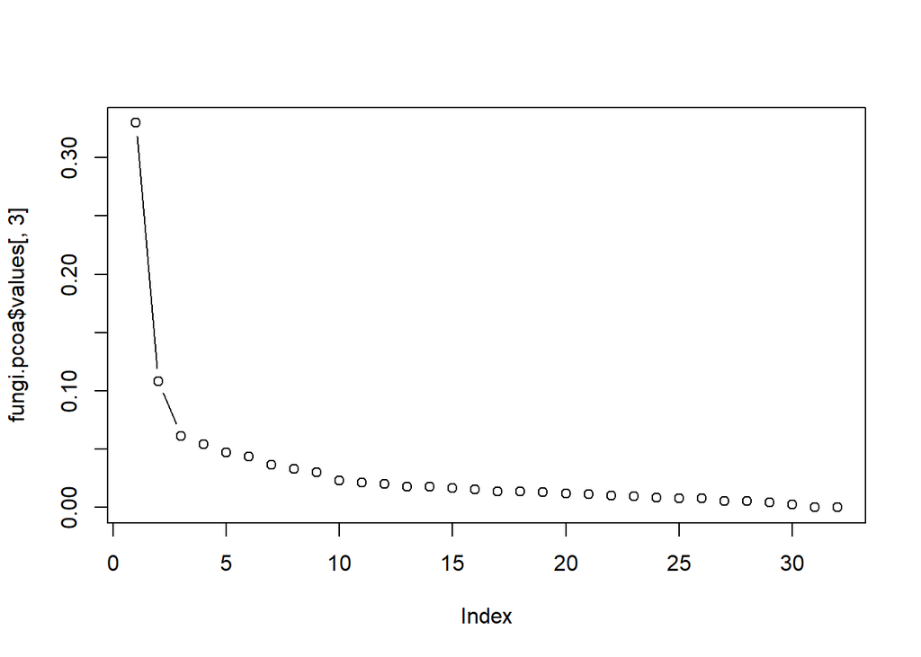

```r
plot(fungi.pcoa$values[,3], type = "b")
```

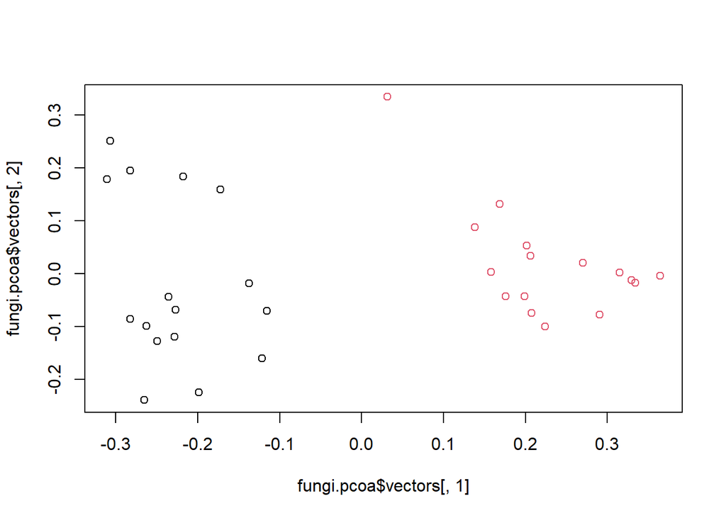

```r
plot(fungi.pcoa$vectors[,1], fungi.pcoa$vectors[,2], col = fungi.env$moist)
```

PCoA explains 44% of variation in the first two axes (relative corrected eigenvalues, PCoA1 = 0.33, PCoA2 = 0.11). After the second axis, additional variation explained per axis decreases dramatically. Due to the diminishing returns on further axes, PCoA1 and PCoA2 are sufficient to explore the data.

Preliminary plots of PCoA1 and PCoA2 show a clear separation by soil treatment along PCoA1.

### nMDS

I compared the PCoA with a non-metric Multidimensional Scaling (nMDS) ordination. NMDS is an iterative ordination that finds the lowest-stress solution through multiple random starts. I first ran the nMDS with 2 axes to compare to the first 2 PCoA axes.

```r
set.seed(42)

fungi.nmds.2D <- metaMDS(fungi[,-1], k = 2, distance = "bray",
                      try = 40, trymax = 40)
```

```
## Square root transformation
## Wisconsin double standardization
## *** Best solution was not repeated -- monoMDS stopping criteria:
##     38: stress ratio > sratmax
##      2: scale factor of the gradient < sfgrmin
```

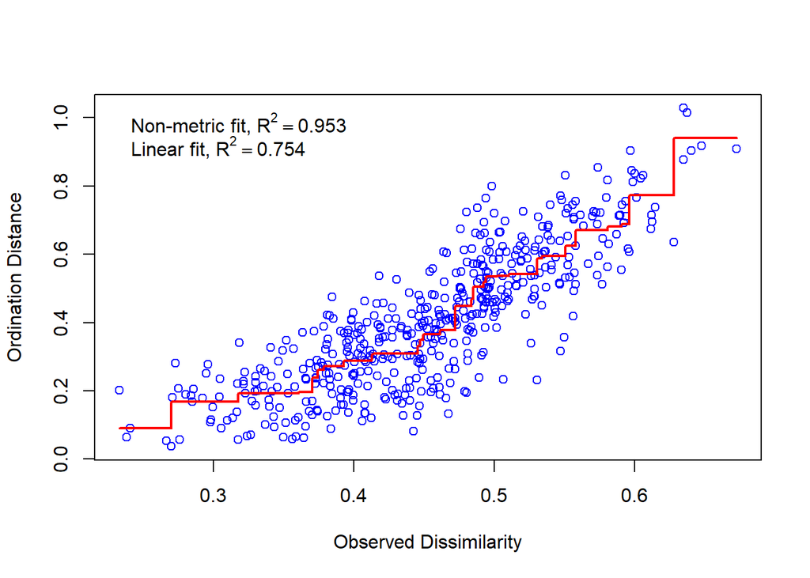

```r
stressplot(fungi.nmds.2D)
```

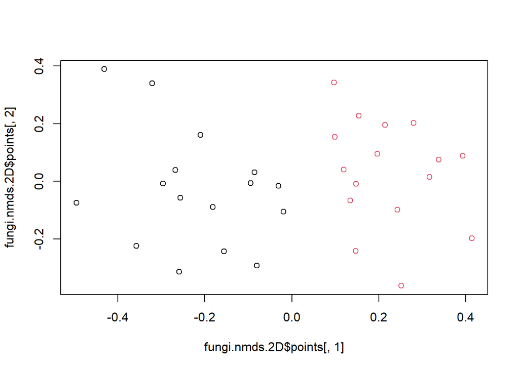

```r
plot(fungi.nmds.2D$points[,1], fungi.nmds.2D$points[,2], col = fungi.env$moist)
```

Non-metric fit of the nMDS was rather high ($R^2$ = 0.953) but no repeated solution with stress below 0.2 was found with 40 random starts. Preliminary plots showed a similar separation of wet and dry treatment groups along nMDS1, but it was less dramatic than the separation on PCoA1.

I expanded the nMDS to include 3 axes to see if a more stable solution could be found with additional variaton.

```r
set.seed(42)

fungi.nmds.3D <- metaMDS(fungi[,-1], k = 3, distance = "bray",
                      try = 40, trymax = 40)
```

```
## Square root transformation
## Wisconsin double standardization
## *** Best solution repeated 1 times
```

```r
fungi.nmds.3D
```

```
##
## Call:
## metaMDS(comm = fungi[, -1], distance = "bray", k = 3, try = 40,      trymax = 40)
##
## global Multidimensional Scaling using monoMDS
##
## Data:     wisconsin(sqrt(fungi[, -1]))
## Distance: bray
##
## Dimensions: 3
## Stress:     0.1568465
## Stress type 1, weak ties
## Best solution was repeated 1 time in 40 tries
## The best solution was from try 30 (random start)
## Scaling: centring, PC rotation, halfchange scaling
## Species: expanded scores based on 'wisconsin(sqrt(fungi[, -1]))'
```

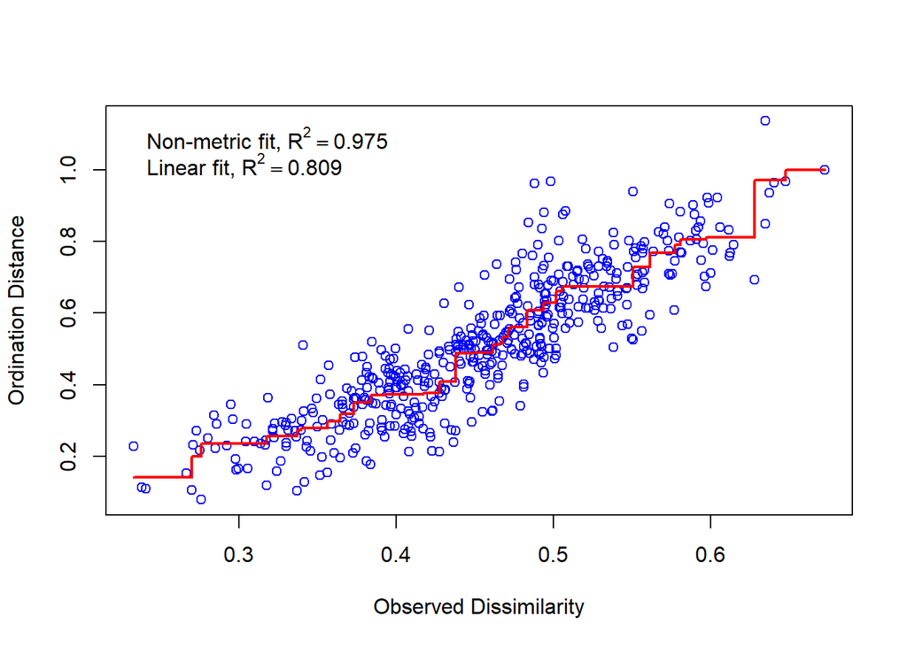

```r
stressplot(fungi.nmds.3D)
```

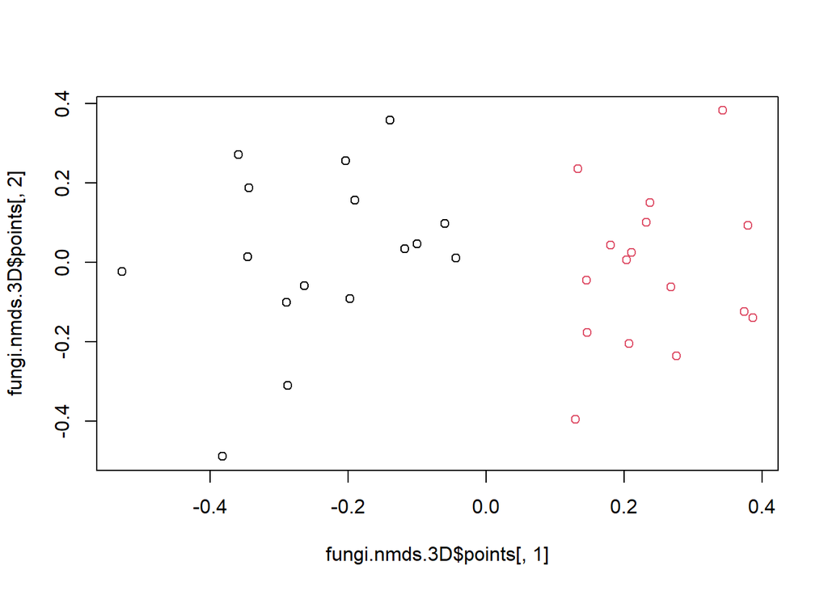

```r
plot(fungi.nmds.3D$points[,1], fungi.nmds.3D$points[,2], col = fungi.env$moist)
```

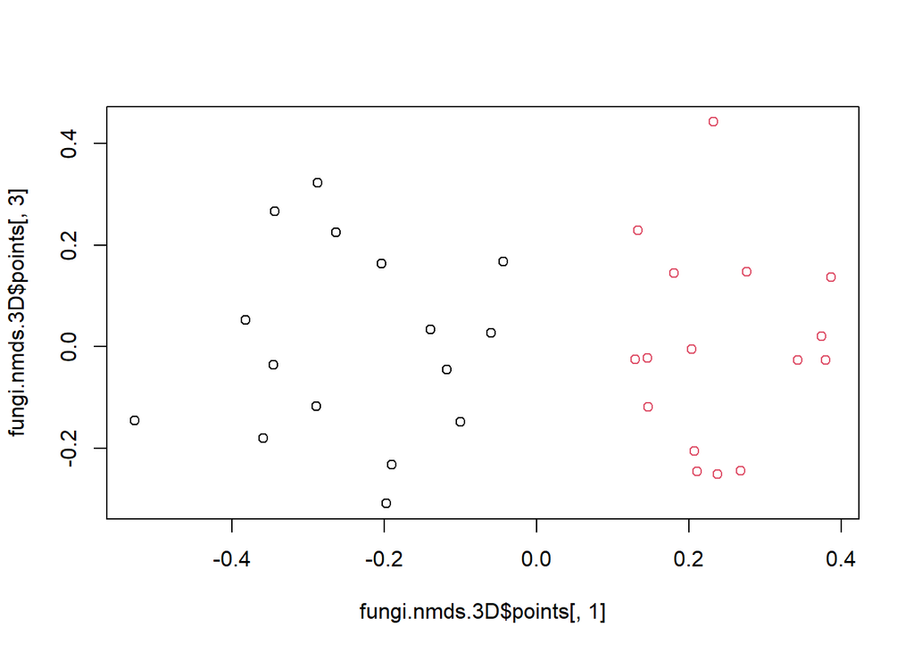

```r
plot(fungi.nmds.3D$points[,1], fungi.nmds.3D$points[,3], col = fungi.env$moist)
```

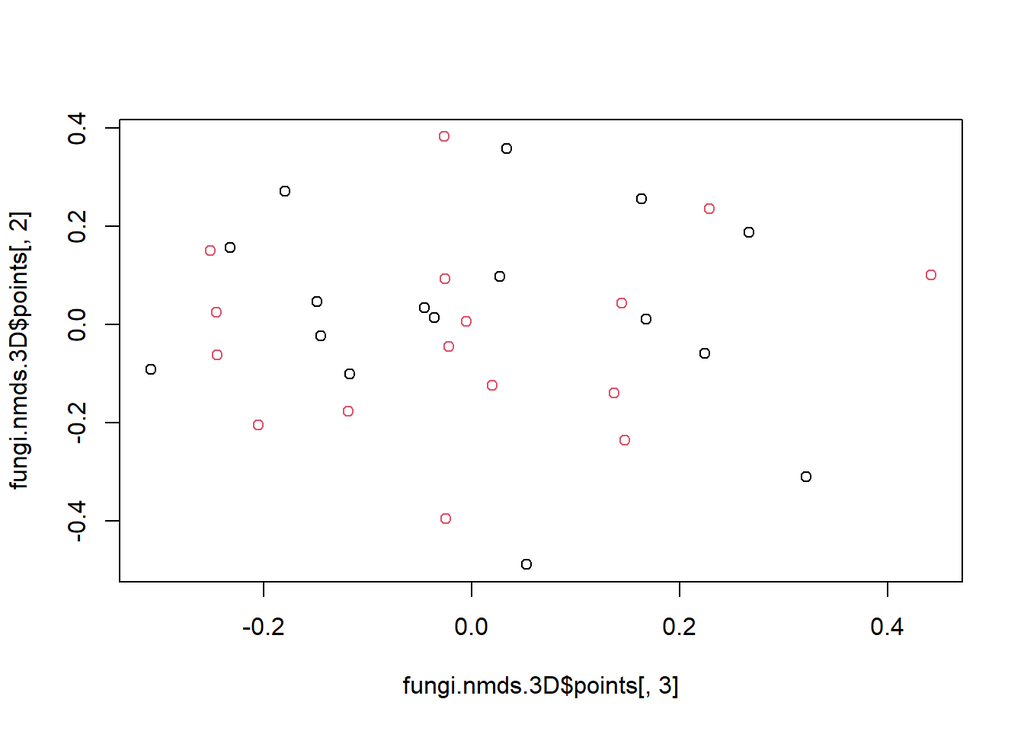

```r
plot(fungi.nmds.3D$points[,3], fungi.nmds.3D$points[,2], col = fungi.env$moist)
```

Three axes resulted in a best solution with stress = 0.157 and non-metric $R^2$ = 0.975. NMDS1 continues to show separation between wet and dry treatments.

## Clustering

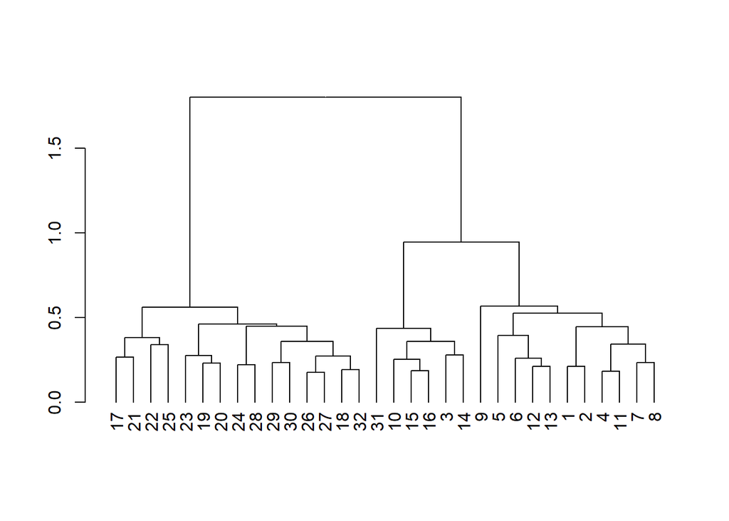

```r
fungi.dist <- vegdist(fungi[,-1], method = "bray")
fungi.hcl <- hclust(fungi.dist, "ward.D2")
fungi.dend <- as.dendrogram(fungi.hcl)
plot(fungi.dend)
```

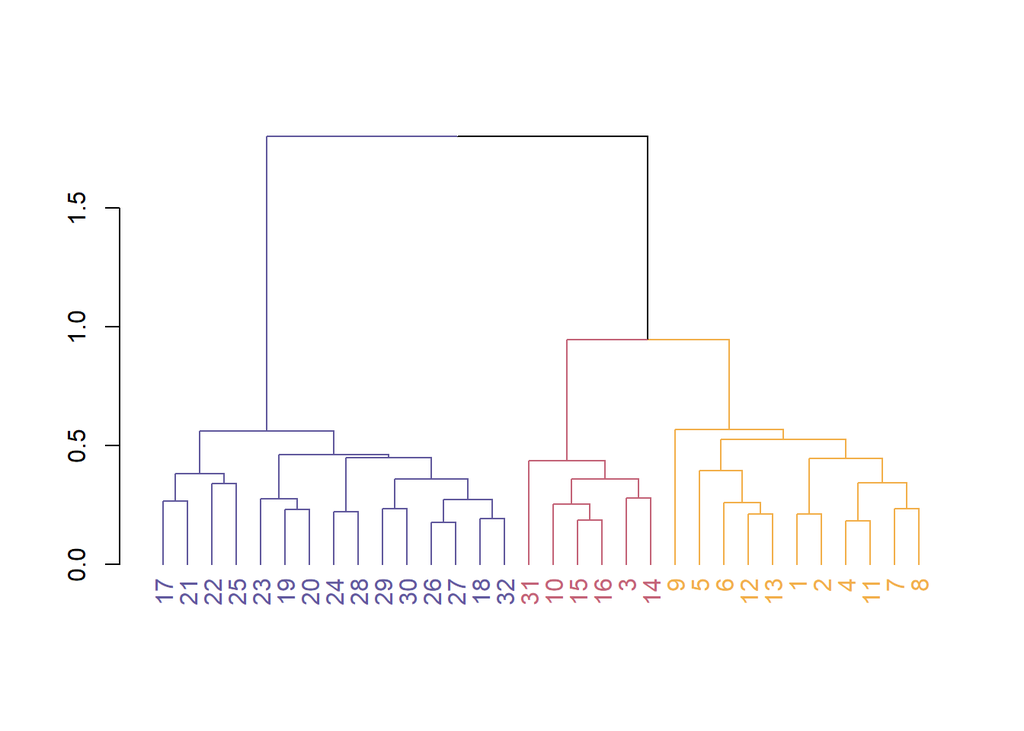

```r
fungi.clust <- cutree(fungi.hcl, k = 3)

fungi.dend <- fungi.dend |>
  color_branches(k = 3, col = pal2) |>
  color_labels(k = 3, col = pal2)

plot(fungi.dend)
```

## Variable Fitting (PCoA)

```r
set.seed(42)

pcoa.fit <- envfit(fungi.pcoa$vectors, fungi.env[,-1], choices = c(1,2))
pcoa.fit
```

```
##
## ***VECTORS
##
##         Axis.1   Axis.2     r2 Pr(>r)
## shoot  0.33475  0.94231 0.3659  0.002 **
## root  -0.35512  0.93482 0.0416  0.560
## total  0.12099  0.99265 0.1335  0.131
## ---
## Signif. codes:  0 '***' 0.001 '**' 0.01 '*' 0.05 '.' 0.1 ' ' 1
## Permutation: free
## Number of permutations: 999
##
## ***FACTORS:
##
## Centroids:
##            Axis.1  Axis.2
## moistdry  -0.2260 -0.0183
## moistwet   0.2260  0.0183
## popjumbo  -0.0180  0.0000
## popmpg     0.0322 -0.0615
## popportal -0.0341  0.0697
## popsandy   0.0261 -0.0160
##
## Goodness of fit:
##           r2 Pr(>r)
## moist 0.6977  0.001 ***
## pop   0.0392  0.845
## ---
## Signif. codes:  0 '***' 0.001 '**' 0.01 '*' 0.05 '.' 0.1 ' ' 1
## Permutation: free
## Number of permutations: 999
```

```r
# nMDS Scores and Clusters for Abundance Dataframe for Plotting
fungiPlot <- data.frame(
  PCOA1 <- fungi.pcoa$vectors[,1],
  PCOA2 <- fungi.pcoa$vectors[,2],
  Cluster <- as.factor(fungi.clust),
  Moist <- fungi.env$moist)
colnames(fungiPlot) <- c("PCOA1", "PCOA2", "Cluster")

# Environmental Variables Dataframe for Plotting
vecPlot <- as.data.frame(scores(pcoa.fit,
                                display = "vectors"))

vecPlot <- cbind(vecPlot,
                 Vname = rownames(vecPlot),
                 Pvalues = pcoa.fit$vectors$pvals,
                 R_squared = pcoa.fit$vectors$r)

centPlot <- as.data.frame(scores(pcoa.fit,
                                 display = "factors"))
centPlot <- cbind(centPlot,
                 Factor_name = rownames(centPlot),
                 Pvalues = pcoa.fit$factors$pvals,
                 R_squared = pcoa.fit$factors$r)


# Filter by significant p value (not necessary here but kept for reference)
# vecPlot <- subset(vecPlot, Pvalues < 0.05)

# Species Scores Dataframe for Plotting

fungi.scores <- as.data.frame(wascores(fungi.pcoa$vectors, fungi[,-1]))

plot.center <- fungiPlot[,-4] |>
  group_by(Cluster) |>
  summarise(
    Axis1.center = mean(PCOA1),
    Axis2.center = mean(PCOA2),
    )
```

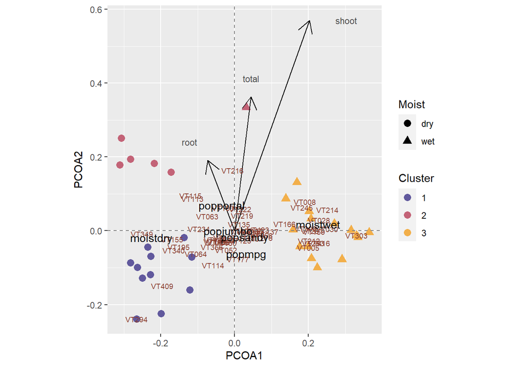

```r
# Ordination Plot
plot1 <- ggplot() +
  geom_point(data = fungiPlot,
             aes(x = PCOA1, y = PCOA2,
                 color = Cluster,
                 shape = Moist),
                 size = 3) +
  coord_fixed() +
  xlab("PCOA1") +
  ylab("PCOA2") +
  scale_color_manual(values = pal2) +
  geom_segment(data = vecPlot,
               aes(x = 0, xend = Axis.1,
                   y = 0, yend = Axis.2),
               arrow =
                 arrow(length = unit(0.5, "cm"))) +
  geom_text(data = fungi.scores,
            aes(x = Axis.1, y = Axis.2),
            label = rownames(fungi.scores),
            size = 2.5, color = "coral4") +
  geom_text(data = vecPlot,
            aes(x = Axis.1, y = Axis.2,
                label = Vname),
            color = "grey30",
            size = 3,
            nudge_x = c(0.1, -0.05, 0, -0.1, 0, 0),
            nudge_y = c(0, 0.05, 0.05, 0, -0.025, -0.025)) +
  # add axes at 0,0
  geom_hline(yintercept = 0, linetype = "dashed", colour = "grey50") +
  geom_vline(xintercept = 0, linetype = "dashed", colour = "grey50") +
  # add centroids
  geom_text(data = centPlot,
             aes(x = Axis.1, y = Axis.2, label = Factor_name))
plot1
```

## Variable Fitting (NMDS)

```r
set.seed(42)

my.fit <- envfit(fungi.nmds.3D, fungi.env[,-1], choices = c(1,2,3))
my.fit
```

```
##
## ***VECTORS
##
##          NMDS1    NMDS2    NMDS3     r2 Pr(>r)
## shoot  0.59507 -0.77155  0.22494 0.1672  0.137
## root  -0.50995 -0.28080  0.81308 0.0846  0.484
## total  0.03099 -0.69863  0.71481 0.0660  0.578
## Permutation: free
## Number of permutations: 999
##
## ***FACTORS:
##
## Centroids:
##             NMDS1   NMDS2   NMDS3
## moistdry  -0.2408  0.0221  0.0030
## moistwet   0.2408 -0.0221 -0.0030
## popjumbo  -0.0448  0.0430  0.0151
## popmpg     0.0066  0.1181  0.0079
## popportal -0.0055 -0.0807 -0.0714
## popsandy   0.0501 -0.0710  0.0475
##
## Goodness of fit:
##           r2 Pr(>r)
## moist 0.4083  0.001 ***
## pop   0.0669  0.737
## ---
## Signif. codes:  0 '***' 0.001 '**' 0.01 '*' 0.05 '.' 0.1 ' ' 1
## Permutation: free
## Number of permutations: 999
```

```r
# nMDS Scores and Clusters for Abundance Dataframe for Plotting
fungiPlot <- data.frame(
  NMDS1 <- fungi.nmds.3D$points[,1],
  NMDS2 <- fungi.nmds.3D$points[,2],
  NMDS3 <- fungi.nmds.3D$points[,3],
  Cluster <- as.factor(fungi.clust))
colnames(fungiPlot) <- c("NMDS1", "NMDS2", "NMDS3", "Cluster")

# Environmental Variables Dataframe for Plotting
vecPlot <- as.data.frame(scores(my.fit,
                                display = "vectors"))

vecPlot <- cbind(vecPlot,
                 Vname = rownames(vecPlot),
                 Pvalues = my.fit$vectors$pvals,
                 R_squared = my.fit$vectors$r)

centPlot <- as.data.frame(scores(my.fit,
                                 display = "factors"))
centPlot <- cbind(centPlot,
                 Factor_name = rownames(centPlot),
                 Pvalues = my.fit$factors$pvals,
                 R_squared = my.fit$factors$r)


# Filter by significant p value (not necessary here but kept for reference)
# vecPlot <- subset(vecPlot, Pvalues < 0.05)

# Species Scores Dataframe for Plotting
Species1 <- fungi.nmds.3D$species[,1]
Species2 <- fungi.nmds.3D$species[,2]
Species3 <- fungi.nmds.3D$species[,3]
Names <- rownames(fungi.nmds.3D$species)
speciesPlot <- data.frame(Species1, Species2, Names)

plot.center <- fungiPlot |>
  group_by(Cluster) |>
  summarise(
    Axis1.center = mean(NMDS1),
    Axis2.center = mean(NMDS2),
    Axis3.center = mean(NMDS3)
    )
```

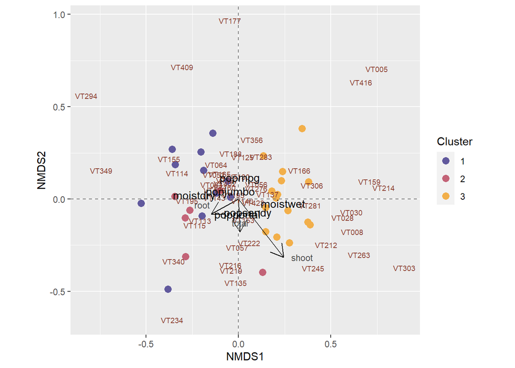

```r
# Ordination Plot
plot1 <- ggplot() +
  geom_point(data = fungiPlot,
             aes(x = NMDS1, y = NMDS2, color = Cluster),
                 size = 3) +
  coord_fixed() +
  xlab("NMDS1") +
  ylab("NMDS2") +
  scale_color_manual(values = pal2) +
  geom_segment(data = vecPlot,
               aes(x = 0, xend = NMDS1,
                   y = 0, yend = NMDS2),
               arrow =
                 arrow(length = unit(0.5, "cm"))) +
  geom_text(data = speciesPlot,
            aes(x = Species1, y = Species2,
                label = Names),
            size = 2.5, color = "coral4") +
  geom_text(data = vecPlot,
            aes(x = NMDS1, y = NMDS2,
                label = Vname),
            color = "grey30",
            size = 3,
            nudge_x = c(0.1, -0.05, 0, -0.1, 0, 0),
            nudge_y = c(0, 0.05, 0.05, 0, -0.025, -0.025)) +
  # add axes at 0,0
  geom_hline(yintercept = 0, linetype = "dashed", colour = "grey50") +
  geom_vline(xintercept = 0, linetype = "dashed", colour = "grey50") +
  # add centroids
  geom_text(data = centPlot,
             aes(x = NMDS1, y = NMDS2, label = Factor_name))
plot1
```

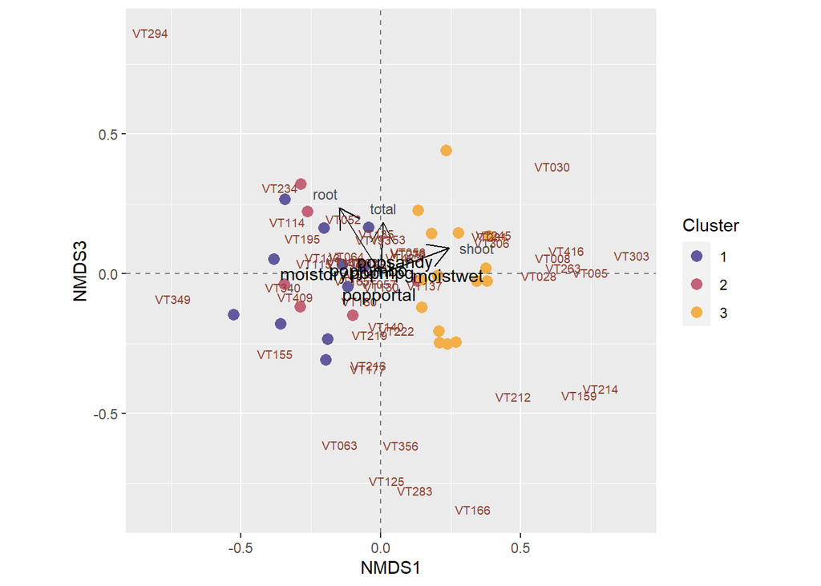

```r
# Ordination Plot
plot2 <- ggplot() +
  geom_point(data = fungiPlot,
             aes(x = NMDS1, y = NMDS3, color = Cluster),
                 size = 3) +
  coord_fixed() +
  xlab("NMDS1") +
  ylab("NMDS3") +
  scale_color_manual(values = pal2) +
  geom_segment(data = vecPlot,
               aes(x = 0, xend = NMDS1,
                   y = 0, yend = NMDS3),
               arrow =
                 arrow(length = unit(0.5, "cm"))) +
  geom_text(data = speciesPlot,
            aes(x = Species1, y = Species3,
                label = Names),
            size = 2.5, color = "coral4") +
  geom_text(data = vecPlot,
            aes(x = NMDS1, y = NMDS3,
                label = Vname),
            color = "grey30",
            size = 3,
            nudge_x = c(0.1, -0.05, 0, -0.1, 0, 0),
            nudge_y = c(0, 0.05, 0.05, 0, -0.025, -0.025)) +
  # add axes at 0,0
  geom_hline(yintercept = 0, linetype = "dashed", colour = "grey50") +
  geom_vline(xintercept = 0, linetype = "dashed", colour = "grey50") +
  # add centroids
  geom_text(data = centPlot,
             aes(x = NMDS1, y = NMDS3, label = Factor_name))
plot2
```

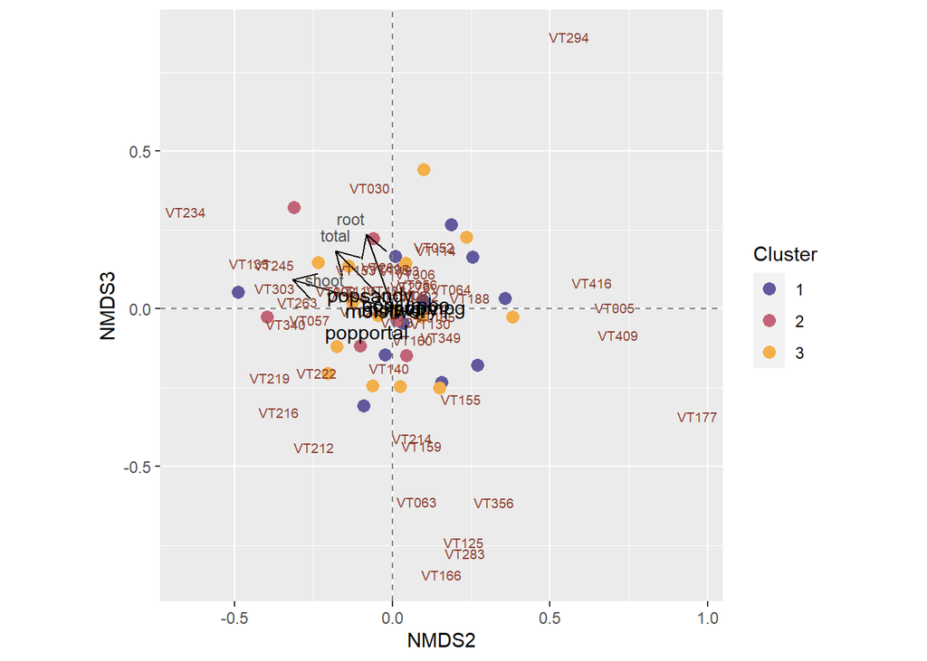

```r
# Ordination Plot
plot3 <- ggplot() +
  geom_point(data = fungiPlot,
             aes(x = NMDS2, y = NMDS3, color = Cluster),
                 size = 3) +
  coord_fixed() +
  xlab("NMDS2") +
  ylab("NMDS3") +
  scale_color_manual(values = pal2) +
  geom_segment(data = vecPlot,
               aes(x = 0, xend = NMDS2,
                   y = 0, yend = NMDS3),
               arrow =
                 arrow(length = unit(0.5, "cm"))) +
  geom_text(data = speciesPlot,
            aes(x = Species2, y = Species3,
                label = Names),
            size = 2.5, color = "coral4") +
  geom_text(data = vecPlot,
            aes(x = NMDS2, y = NMDS3,
                label = Vname),
            color = "grey30",
            size = 3,
            nudge_x = c(0.1, -0.05, 0, -0.1, 0, 0),
            nudge_y = c(0, 0.05, 0.05, 0, -0.025, -0.025)) +
  # add axes at 0,0
  geom_hline(yintercept = 0, linetype = "dashed", colour = "grey50") +
  geom_vline(xintercept = 0, linetype = "dashed", colour = "grey50") +
  # add centroids
  geom_text(data = centPlot,
             aes(x = NMDS2, y = NMDS3, label = Factor_name))
plot3
```

# PERMANOVA

## All Factors

```r
# Set seed: pseudo-random number generator. Allows for replication.
set.seed(42)
pcoa.fit
```

```
##
## ***VECTORS
##
##         Axis.1   Axis.2     r2 Pr(>r)
## shoot  0.33475  0.94231 0.3659  0.002 **
## root  -0.35512  0.93482 0.0416  0.560
## total  0.12099  0.99265 0.1335  0.131
## ---
## Signif. codes:  0 '***' 0.001 '**' 0.01 '*' 0.05 '.' 0.1 ' ' 1
## Permutation: free
## Number of permutations: 999
##
## ***FACTORS:
##
## Centroids:
##            Axis.1  Axis.2
## moistdry  -0.2260 -0.0183
## moistwet   0.2260  0.0183
## popjumbo  -0.0180  0.0000
## popmpg     0.0322 -0.0615
## popportal -0.0341  0.0697
## popsandy   0.0261 -0.0160
##
## Goodness of fit:
##           r2 Pr(>r)
## moist 0.6977  0.001 ***
## pop   0.0392  0.845
## ---
## Signif. codes:  0 '***' 0.001 '**' 0.01 '*' 0.05 '.' 0.1 ' ' 1
## Permutation: free
## Number of permutations: 999
```

```r
str(fungi.env)
```

```
## 'data.frame':    32 obs. of  6 variables:
##  $ ID   : Factor w/ 32 levels "K01","K02","K03",..: 1 2 3 4 5 6 7 8 9 10 ...
##  $ moist: Factor w/ 2 levels "dry","wet": 1 1 1 1 1 1 1 1 1 1 ...
##  $ pop  : Factor w/ 4 levels "jumbo","mpg",..: 1 1 1 1 2 2 2 4 4 4 ...
##  $ shoot: num  0.622 0.526 1.099 0.541 0.482 ...
##  $ root : num  0.792 0.829 1.824 1.218 0.944 ...
##  $ total: num  1.41 1.35 2.92 1.76 1.43 ...
```

```r
# Run permutation test with adonis2() - from vegan package
fungi.perm <- adonis2(Y ~ fungi.env$moist +
                        fungi.env$shoot +
                        fungi.env$total +
                        fungi.env$root +
                        fungi.env$pop,
                      method = "bray")
fungi.perm
```

```
## Permutation test for adonis under reduced model
## Terms added sequentially (first to last)
## Permutation: free
## Number of permutations: 999
##
## adonis2(formula = Y ~ fungi.env$moist + fungi.env$shoot + fungi.env$total + fungi.env$root + fungi.env$pop, method = "bray")
##                 Df SumOfSqs      R2       F Pr(>F)
## fungi.env$moist  1   1.6480 0.43964 25.9191  0.001 ***
## fungi.env$shoot  1   0.1731 0.04618  2.7224  0.035 *
## fungi.env$total  1   0.0626 0.01671  0.9850  0.394
## fungi.env$pop    3   0.2752 0.07342  1.4427  0.159
## Residual        25   1.5896 0.42405
## Total           31   3.7485 1.00000
## ---
## Signif. codes:  0 '***' 0.001 '**' 0.01 '*' 0.05 '.' 0.1 ' ' 1
```

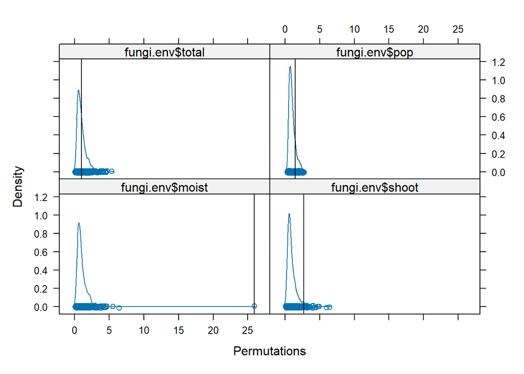

```r
fungi.permstats <- permustats(fungi.perm)
densityplot(fungi.permstats)
```